# Predictive modeling on Heart Disease(CAD)

Zackary Petrasek

October 24th, 2026

# 1 Introduction

According to the CDC, Coronary Artery Disease (CAD) affects 5% of Americans, and around 2% of people with CAD die from it every year. Being able to successfully test people to find this disease can be very important to make sure people get the proper treatment. It is important to note before going into the data set that the population is very specifically people who are already getting tested for CAD, this means that the interpretations are NOT for the general population.

In the assignment we will go over our data set, go into exploratory analysis, move into the model selection, report the final model, and finally go into conclusion and discussions of the project.

# 2 Data Source

The heart disease data set contains 920 observations on 16 variables(2 will be removed before exploratory analysis so 14 remaining variables). The data set is originates from the UCI machine learning data repository, gathered by Detrano et al. (1989). However, I accessed the data from kaggle (https://www.kaggle.com/datasets/redwankarimsony/heart-disease-data?resource=download), as the data was not all processed in the UCI data repository. The data looks specifically at the Cleveland data as it has the least amount of observations with missing values. If we were to look at all four sites from the original data set, we would likely have to drop some variables known to be clinically important, as other sites did not record values for these variables. Due to this we will be left with 304 observations.

There are 14 variables in the data set.

1. **age**: Age in years(discrete, numeric)
2. **sex**: Male or Female (binary, categorical)
3. **cp**: Chest pain type, typical angina, atypical angina, non-anginal, or asymptomatic (4-level, categorical)
4. **bp**: Resting systolic blood pressure (discrete, numeric, in mmHg)
5. **chol**: Serum cholesterol (discrete, numeric, in mg/dl)
6. **fbs**: Fasting blood sugar, True if >120 mg/dl, False if not (binary, categorical)
7. **ecg**: Resting electrocardiograph results, showing probable or definite left ventricular hypertrophy(by Estes’ criteria), having ST-T wave abnormality(T wave inversions and/or ST elevation or depression greater than .05 mV), or normal. (Three-level, categorical)
8. **maxbpm**: Maximum heart rate (discrete, numeric, BpM)
9. **exang**: Exercise induced angina, true if yes, false if no (binary, categorical)
10. **oldpeak**: ST depression induced by exercise relative to rest (continuous, numeric, mm)
11. **slope**: Slope of the peak exercise ST segment, downslopping, flat, or upsloping. (Three-level, categorical)
12. **ca**: Number of major vessels colored by fluorosopy, 0, 1, 2, 3. (discrete, numeric)
13. **thal**: Thalassemia status, normal, fixed defect, or reversible defect.(Three-level, categorical)
14. **CAD**: Testing variable (5-level categorical, 0 for no CAD and 1-4 for increasing stages of CAD, which will turn into binary response variable, with 0 for no CAD, and 1 for any stage of CAD)

The following code loads the heart disease data set, changes characters to factors, and assesses for missingness.

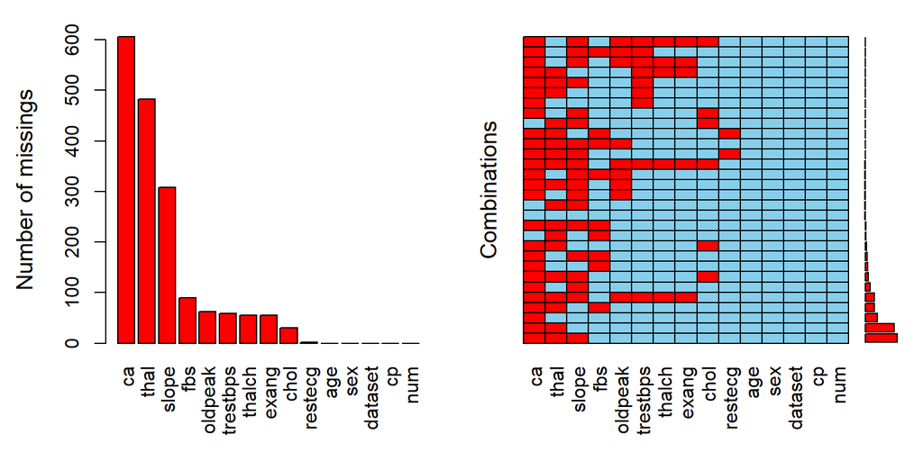

Figure 1: Missingness by variable, non-Cleveland sites

```
 Variables sorted by number of missings:
 Variable Count
       ca   606
     thal   483
    slope   308
      fbs    90
  oldpeak    62
 trestbps    59
   thalch    55
    exang    55
     chol    30
  restecg     2
      age     0
      sex     0
  dataset     0
       cp     0
      num     0
```

```r
# read in data set
url <- "https://raw.githubusercontent.com/ZackaryPetrasek/STA321/main/homeworks/hw4/heart.csv"
heart <- read_csv(url)
# remove id from data set
heart$id <- NULL
# check for missingness in non-Cleveland sites
others <- heart[heart$dataset != "Cleveland", ]
miss1 <- aggr(others, numbers = TRUE, prop = FALSE, sortVar = TRUE)
```

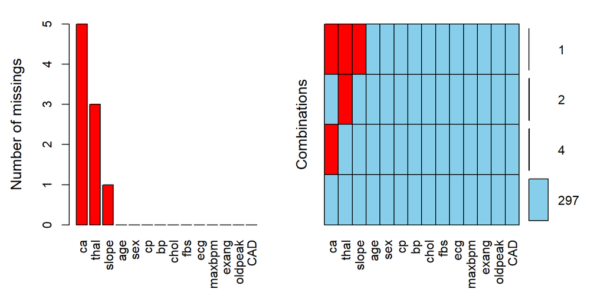

Figure 2: Missingness by variable, Cleveland data

```
 Variables sorted by number of missings:
 Variable Count
       ca     5
     thal     3
    slope     1
      age     0
      sex     0
       cp     0
       bp     0
     chol     0
      fbs     0
      ecg     0
   maxbpm     0
    exang     0
  oldpeak     0
      CAD     0
```

```r
#get cleveland data set by itself
heart <- heart[heart$dataset == "Cleveland", ]
#clean data set to match what we want to work with
heart$dataset <- NULL
names(heart)[c(4,7,8,14)] <- c("bp", "ecg", "maxbpm", "CAD")
heart <- heart %>% mutate(CAD = if_else(CAD > 0, 1, 0))
heart <- heart %>% mutate(across(where(is.character), as.factor))
#check for missingness in Cleveland data set
miss2 <- aggr(heart, numbers = TRUE, prop = FALSE, sortVar = TRUE)
```

```r
heart <- heart[complete.cases(heart), ]
```

As you can see in Figure 1, nearly every single value for ca is missing for all of the locations outside of Cleveland, and there are lots of other missing values for other variables, so we will stick with just the Cleveland data. Looking at Figure 2, there are 7 observations with missing values in our data set. As we still have more than 15 observations per predictor variable, we can simply remove these observations without worrying about losing too much data. After removing these observations we are still left with 297 observations with 14 variables.

# 3 Research Questions

The research questions of this assignment are:

- Which is the best logistic regression predictive model out of our candidate models?
- What is the accuracy, sensitivity, and specificity of the final model?

As the data does not come from a random sample of the entire population, so it should not be used to make predictions for the general population.

# 4 Exploratory Analysis

In order to make sure the data is ready to be put into a model we first need to do some exploratory analysis.

## 4.1 Numeric variables

First off we will look at the distribution of the variables to see if any variables need to be transformed at all, and then check for multicollinearity issues in the data.

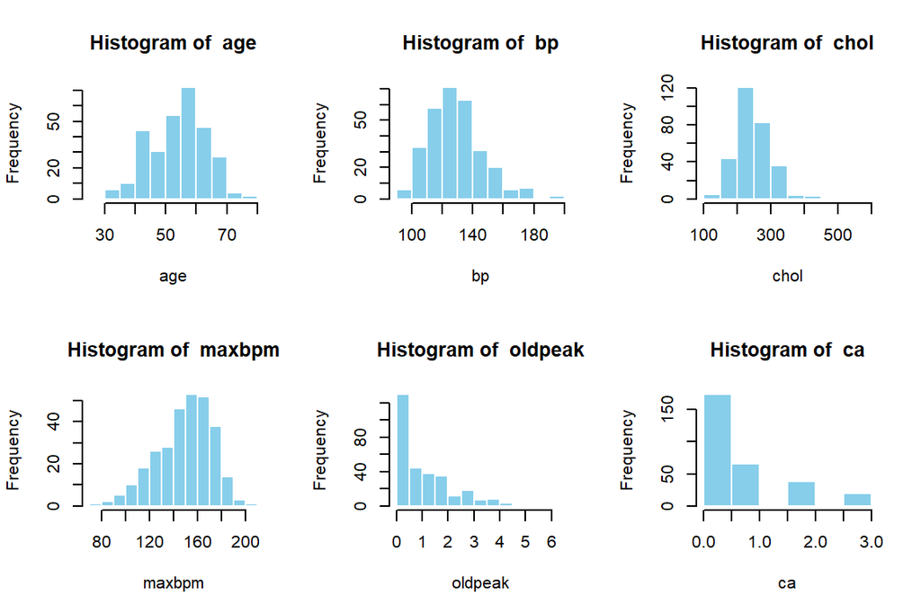

Variable histogram plots

```r
par(mfrow = c(2, 3)) # Arrange plots in a 2x3 grid
hquant <- Filter(is.numeric, heart)
for (i in 1:6) {
  #create histograms for each variable to show distribution patterns
  hist(hquant[[i]], main = paste("Histogram of ", names(hquant)[i]),
  xlab = names(hquant)[i], col = "skyblue", border = "white")
}
```

Ca and oldpeak seem slightly skewed, which is not necessarily a big deal but worth looking into. As ca is already a discrete numeric variables we do not need to group it further, but based on the skewed distribution and clinically an oldpeak value of 1 or more being considered abnormal, we will discretize oldpeak. We will call this variable abnpeak with a value of one or higher being TRUE while a value less than one being FALSE.

```r
#discretize oldpeak by breaking it up into groups
heart$abnpeak <- heart$oldpeak>=1
heart$oldpeak<- NULL
```

## 4.2 Standardizing Numeric Variables

Due to the model being specifically used for predictor, the best practice is to scale the remaining numeric variables. This is because interpretation of the variables does not matter, and looking at the z-scores of the numeric variables gives a better understanding of the value compared to the rest of the data set.

```r
# standardize remaining numeric variables

heart$bp = (heart$bp-mean(heart$bp))/sd(heart$bp)
heart$chol = (heart$chol-mean(heart$chol))/sd(heart$chol)
heart$maxbpm = (heart$maxbpm-mean(heart$maxbpm))/sd(heart$maxbpm)
heart$age = (heart$age-mean(heart$age))/sd(heart$age)
```

In summary of the 6 numeric variables:

- We standardized bp, chol, maxbpm, and age.
- We discretized oldpeak as clinically a value of 1 or more signifies an abnormality.
- We left ca untouched.

## 4.3 Categorical Variables

After looking at the numeric variables it is also important to the categorical variables to check for sparseness.

```r
#look at all categorical variables from the data set, gather their count, and percent of observations, and create chart to look for sparsity in the categorical variables.
heart[sapply(heart, is.factor)] %>%
  pivot_longer(cols = everything(), names_to = "Variable", values_to = "Category") %>%
  count(Variable, Category) %>%
  group_by(Variable) %>%
  mutate(Percentage = round(n / sum(n) * 100, 1)) %>%
  gt(groupname_col = "Variable") %>%
  cols_label( Category = "Category Level", n = "Count", Percentage = "Percentage (%)") %>%
  tab_header(title = "Summary of All Categorical Variables", subtitle = "Combined frequency and percentage breakdown")
```

Summary of All Categorical Variables

Combined frequency and percentage breakdown

| Category Level | Count | Percentage (%) |
| --- | --- | --- |
| cp |  |  |
| asymptomatic | 142 | 47.8 |
| atypical angina | 49 | 16.5 |
| non-anginal | 83 | 27.9 |
| typical angina | 23 | 7.7 |
| ecg |  |  |
| lv hypertrophy | 146 | 49.2 |
| normal | 147 | 49.5 |
| st-t abnormality | 4 | 1.3 |
| sex |  |  |
| Female | 96 | 32.3 |
| Male | 201 | 67.7 |
| slope |  |  |
| downsloping | 21 | 7.1 |
| flat | 137 | 46.1 |
| upsloping | 139 | 46.8 |
| thal |  |  |
| normal | 164 | 55.2 |
| fixed defect | 18 | 6.1 |
| reversable defect | 115 | 38.7 |

We can see that there are only 4 observations with st-t abnormality, this is incredibly sparse and any interpretation on this level of the variable would not have much meaning. Instead, we could instead re-group ecg to have a normal level and an abnormality level, grouping lv hypertrophy and st-t abnormality together. At the same time we should consider re-leveling some of our other categorical variables. At the moment thal and slope have sparse levels as their base level, while they are not sparse enough to require re-grouping, it would be a good idea to change the base level of these variables.

```r
#Regroup ecg
heart <- heart %>% mutate(ecg = if_else(ecg=="normal", "normal", "abnormal"))
heart <- heart %>% mutate(across(where(is.character), as.factor))
#Re-level thal, slope, ecg
   heart$thal  <- relevel(heart$thal,  ref = "normal")
   heart$slope <- relevel(heart$slope, ref = "flat")
   heart$ecg <- relevel(heart$ecg, ref = "normal")
```

Next we need to check for any multicollinearity issues, and we can do this using the VIF function.

```r
#use vif function to check for multicollinearity issues
model <- lm(CAD ~ ., data=heart)
vif(model)
```

```
            GVIF Df GVIF^(1/(2*Df))
age     1.501831  1        1.225492
sex     1.326481  1        1.151730
cp      1.684775  3        1.090830
bp      1.211720  1        1.100782
chol    1.153271  1        1.073905
fbs     1.111851  1        1.054443
ecg     1.115256  1        1.056057
maxbpm  1.748001  1        1.322120
exang   1.431236  1        1.196343
slope   1.743687  2        1.149125
ca      1.321801  1        1.149696
thal    1.653561  2        1.133979
abnpeak 1.584886  1        1.258923
```

As we can see using the VIF function, all of the GVIF^(1/(2*Df)) values are under 1.4, which is good as values above 2 are when we start to think about multicollinearity issues. So we do not have to worry about multicollinearity in this data set.

The response variable, `CAD`, is a binary categorical variable. In the data set of 297 subjects, 137 (46.1%) were diagnosed with CAD. From a modeling perspective, this distribution does not indicate a class imbalance that would bias the results.

# 5 Data Split - Training and Testing Data

We **randomly** split the data into two subsets. 75% of the data will be used as training data. We will use the training data to search the candidate models, validate them and identify the final model using the cross-validation method. The 25% of the hold-up sample will be used for assessing the performance of the final model.

```r
# set seed for reproducibility
set.seed(26)
# splitting data: 75% training and 25% testing
n <- dim(heart)[1]
train.n <- round(0.75*n)
train.id <- sample(1:n, train.n, replace = FALSE)
# training and testing data sets
train <- heart[train.id, ]
test <- heart[-train.id, ]
```

# 6 Best Model Identification

In the previous module, we introduced full and reduced models to set up the scope for searching for the final model. In this case study, we use the full, reduced, and model obtained based on the step-wise variable selection as the three candidate models.

We will find the optimal cut-off point for each model in the cross-validation process to best mirror real world practices. By finding the optimal cut-off point for each model we will see how they best perform, as in real world practices we would usually want to focus on the best instance of the model.

*Note* : Full model contains all variables, reduced model contains ca + cp + thal, and the step-wise model is found for each fold so the formula may change.

## 6.1 Cross-Validation for Model Identification

I will use 10-fold cross-validation to ensure the validation data set has enough CAD cases.

```r
# set seed for reproducibility
set.seed(26)
## 10-fold cross-validation
k=10
## floor() function must be used to avoid producing NA in the subsequent results
fold.size = floor(dim(train)[1]/k)
## PE vectors for candidate models
PE1 = rep(0,k)
PE2 = rep(0,k)
PE3 = rep(0,k)
for(i in 1:k){
  ## Training and testing folds
  valid.id = (fold.size*(i-1)+1):(fold.size*i)
  valid = train[valid.id, ]
  train.dat = train[-valid.id,]
  ##  full model
  candidate01 = glm(CAD ~.,
                    family = binomial(link = "logit"),
                    data = train.dat)
  ## reduced model
  candidate03 = glm(CAD ~ ca + cp + thal,
                    family = binomial(link = "logit"),
                    data = train.dat)
  ##
  candidate02 = stepAIC(candidate03, scope = list(lower=formula(candidate03), upper=formula(candidate01)), direction = "forward", trace = 0)



# generate predicted probabilities from the full model
train.dat$pred <- predict(candidate01, newdata = train.dat, type = "response")
# run cutpointr directly on the new prediction column
opt1 <- cutpointr(data = train.dat, x = pred, class = CAD, method = maximize_metric, metric = youden)

# repeat for the step-wise model
train.dat$pred <- predict(candidate02, newdata = train.dat, type = "response")
opt2 <- cutpointr(data = train.dat, x = pred, class = CAD, method = maximize_metric, metric = youden)

# repeat for reduced model
train.dat$pred <- predict(candidate03, newdata = train.dat, type = "response")
opt3 <- cutpointr(data = train.dat, x = pred, class = CAD, method = maximize_metric, metric = youden)

   # find predicted probabilities of each candidate model
   pred01 = predict(candidate01, newdata = valid, type="response")
   pred02 = predict(candidate02, newdata = valid, type="response")
   pred03 = predict(candidate03, newdata = valid, type="response")

   # use optimal cut-off point to find if the model predicts the value to be true or false
   pre.outcome01 = ifelse((pred01) > opt1$optimal_cutpoint, 1, 0)
   pre.outcome02 = ifelse((pred02) > opt2$optimal_cutpoint, 1, 0)
   pre.outcome03 = ifelse((pred03) > opt3$optimal_cutpoint, 1, 0)

   # use these predictions to find prediction error
   PE1[i] = 1-sum(pre.outcome01 == as.vector(valid$CAD))/length(pred01)
   PE2[i] = 1-sum(pre.outcome02 == as.vector(valid$CAD))/length(pred02)
   PE3[i] = 1-sum(pre.outcome03 == as.vector(valid$CAD))/length(pred03)
}

# take the average of the prediction errors for each model and report in a table
avg.pe = cbind(PE.1 = mean(PE1), PE.2 = mean(PE2), PE.3 = mean(PE3))
pander(avg.pe, caption = "Average of prediction errors of candidate models")
```

Average of prediction errors of candidate models

| PE.1 | PE.2 | PE.3 |
| --- | --- | --- |
| 0.2 | 0.1818 | 0.1818 |

The reduced model and the step-wise model have the same prediction error, slightly lower than the full model. Going solely off of CV we would want to choose the reduced model, as it is simpler than the step-wise model. However, we will also look at ROC analysis to get more information to inform our decision on selecting a final model.

## 6.2 ROC Analysis - Global Performance

The ROC curve as a visual tool is used to compare the **global performance** of binary predictive models. Since it is used for the purpose of model selection, we need to construct ROC curves based on the training data. Next, we will construct ROC curves and calculate the corresponding area under curves (AUCs) using package `pROC`.

The ROC curves of the three candidate models are given below.

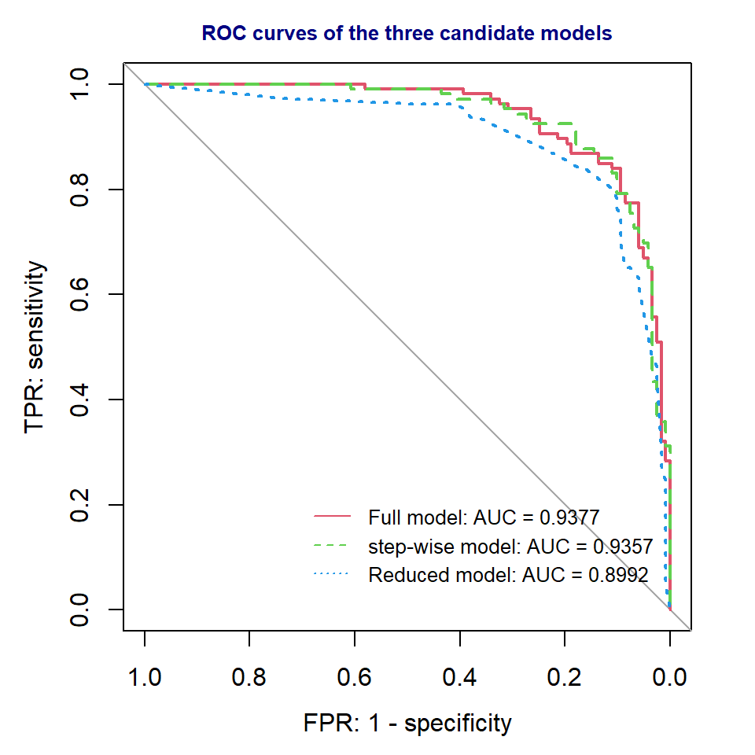

ROC curve

```r
# set seed for reproducibility
set.seed(26)


# create candidate models

#  full model
candidate01 = glm(CAD ~., family = binomial(link = "logit"),
                    data = train)
# reduced model
candidate03 = glm(CAD ~ ca + cp + thal,
                    family = binomial(link = "logit"),
                    data = train)

# step-wise model with lower bound of the reduced model and upper bound of the full mode, with foward selection
candidate02 = stepAIC(candidate03, scope= list( lower=formula(candidate03), upper=formula(candidate01)), direction = "forward", trace = 0)

## find predicted probabilities based on the training data
pred01 = predict.glm(candidate01, newdata = train, type="response")
pred02 = predict.glm(candidate02, newdata = train, type="response")
pred03 = predict.glm(candidate03, newdata = train, type="response")


  ##
  category <- as.numeric(train$CAD == 1)
  ROCobj01 <- pROC::roc(category, as.numeric(pred01))
  ROCobj02 <- pROC::roc(category, as.numeric(pred02))
  ROCobj03 <- pROC::roc(category, as.numeric(pred03))
  AUC01 = round(pROC::auc(ROCobj01), 4)
AUC02 = round(pROC::auc(ROCobj02), 4)
AUC03 = round(pROC::auc(ROCobj03), 4)

# plot ROC curves using pROC's built-in methods

# create the plot
pROC::plot.roc(ROCobj01,
               col = 2,
               lty = 1,
               legacy.axes = TRUE,
               xlim = c(0, 1),
               ylim = c(0, 1),
               xlab = "FPR: 1 - specificity",
               ylab = "TPR: sensitivity",
               main = "ROC curves of the three candidate models", cex.main = 0.8, col.main = "navy")
pROC::lines.roc(ROCobj02, col = 3, lty = 2)
pROC::lines.roc(ROCobj03, col = 4, lty = 3)

# add Legend
legend("bottomright", inset = 0.05,
       legend = c(paste("Full model: AUC =", AUC01),
                  paste("step-wise model: AUC =", AUC02),
                  paste("Reduced model: AUC =", AUC03)),
       col = 2:4, lty = 1:3, cex = 0.8, bty = "n")
```

If we are just looking at the ROC curve we would choose the step-wise model as the final model. This is because we can see from the ROC curve that both full model (AUC=0.9377) and the step-wise model (AUC=0.9357) are better than the reduced model (AUC=0.8992). Paired with the fact that the full and step-wise models have very similar AUCs and the step-wise model is simpler, that would make the step-wise model the best choice.

Looking at the full picture, however, it is also important to look at the reduced model. As ROC favors bigger models when looking at the same data they were trained on, the slight difference in AUC is small relative to the in-sample advantage larger models get. Paired with the fact the reduced model had the same prediction error as the step-wise model, we will choose to continue with the reduced model as it is the simplest.

# 7 Final Model Reporting

Now we can use our test data we cut off earlier to test how well our model is able to predict the randomly selected observations sampled earlier. This will give us an idea of how good of a predictor our data is based on the population. Which again is not the entire population, but people already getting tested for heart disease.

*Note*: Final formula for the reduced model is **CAD ~ ca + cp + thal**.

```r
#set seed
set.seed(26)

#get optimal cutoff point for candidate 3 on full training data
train$pred <- predict(candidate03, newdata = train, type = "response")
opt3 <- cutpointr(data = train, x = pred, class = CAD, method = maximize_metric, metric = youden)

# predict probabilities and apply optimal cutpoint
pred03 = predict(candidate03, newdata = test, type = "response")
pred03.outcome = ifelse(as.vector(pred03) > opt3$optimal_cutpoint, 1, 0)

# extract actual outcomes and ensure factor levels match
actual <- factor(test$CAD, levels = c(0, 1))
predicted_factor <- factor(pred03.outcome, levels = c(0, 1))

# calculate performance metrics
cm <- confusionMatrix(predicted_factor, actual)
accuracy    <- cm$overall["Accuracy"]
sensitivity <- cm$byClass["Sensitivity"]
specificity <- cm$byClass["Specificity"]

# combine into a data frame
metrics_df <- data.frame(
  Value  = round(c(accuracy, sensitivity, specificity), 4)
)

# display as a table
kable(metrics_df,
      format = "markdown",
      col.names = c("Performance Metric", "Score"),
      caption = "Classification Model Evaluation Metrics on Test Data")
```

Classification Model Evaluation Metrics on Test Data

| Performance Metric | Score |
| --- | --- |
| Accuracy | 0.8514 |
| Sensitivity | 0.8140 |
| Specificity | 0.9032 |

Therefore, the final model has an accuracy rate of .8514, meaning about 85.1% of the time the model was able to successfully predict the value of CAD based on the subset of data set aside for testing. It also has a sensitivity of about 81.40%, meaning if a patient has CAD it predicts they do about 81.40% of the time. The specificity is the portion of time the model correctly predicts a false value of CAD given the patient does not have CAD, and the model has a specificity of 90.32%.

**Note**: I used a seed when doing my random samples for the sake of reproducibility , however, if you were to change the seed, or remove the seed, it is possible to get different results which do not line up with the report.

# 8 Conclusion and Summary

In summary, we looked at a medical data set relating to various medical information in relation to a heart disease test, then created a predictive model that was able to predict the result of this test correctly about 85.1% of the time.

Looking back at our research questions:

- Which is the best logistic regression predictive model out of our candidate models?
- What is the accuracy rate, sensitivity, and specificity of the final model?

For the first question it turns out the reduced model was the best of the three candidate models created in the multiple logistic regression (MLR) assignment, having tied lowest prediction error, and only slightly lower AUC compared to the full model and step-wise model.

The accuracy rate of the final model ended up being about 85.1%, with a sensitivity of about 81.40% and a specificity of about 90.32%.

Some practical recommendations for the model would be to only use it on patients who are already being tested for CAD, as that is the population this data comes from, and to note that the model is not perfect and has about a 18.60% chance to give a false negative.

Some limitations of the assignment include:

- The data was not a random sample of the population, but instead a sample of those already being tested for CAD. So the model can not be generalized.
- The data is also almost 40 years old, so new predictors could have already been found, or changes in lifestyle could have occurred making different values more significant.
- Slightly small sample size, would be best to have a some more observations to have a larger training data set.
- ROC favors bigger models in-sample, since we are using nested models the bigger models will almost always have a higher AUC.
- Standardization of variables happened before split, so this means the testing observations have a slight impact on the training.

Some possible ways to improve or continue on the project could be:

- Get more observations with all of the variables, or try to see if the values gathered by the other sites are enough to create a powerful predictive model even with less variables.
- Add in interaction terms to see if they can help improve the model.
- Compare this model to newer and/or different data to see if it works just as well on other data sets.
- Redo the experiment by using a random sample of the population to get a model that could predict for the overall population as well.